# Ford_bike_share

```python
#first import the needed libraries
import pandas as pd
import numpy as np
import random
import matplotlib.pyplot as plt
%matplotlib inline
import seaborn as sb
from matplotlib import rcParams
```

```python
#import fordgobike dataset using pandas
df = pd.read_csv('201902-fordgobike-tripdata.csv')
```

```python
# use info() to get the informtion about dataset
print("Here we can see the basic info about our data like count, data types,columns ")
df.info()
```

```
Here we can see the basic info about our data like count, data types,columns
<class 'pandas.core.frame.DataFrame'>
RangeIndex: 183412 entries, 0 to 183411
Data columns (total 16 columns):
 #   Column                   Non-Null Count   Dtype
---  ------                   --------------   -----
 0   duration_sec             183412 non-null  int64
 1   start_time               183412 non-null  object
 2   end_time                 183412 non-null  object
 3   start_station_id         183215 non-null  float64
 4   start_station_name       183215 non-null  object
 5   start_station_latitude   183412 non-null  float64
 6   start_station_longitude  183412 non-null  float64
 7   end_station_id           183215 non-null  float64
 8   end_station_name         183215 non-null  object
 9   end_station_latitude     183412 non-null  float64
 10  end_station_longitude    183412 non-null  float64
 11  bike_id                  183412 non-null  int64
 12  user_type                183412 non-null  object
 13  member_birth_year        175147 non-null  float64
 14  member_gender            175147 non-null  object
 15  bike_share_for_all_trip  183412 non-null  object
dtypes: float64(7), int64(2), object(7)
memory usage: 22.4+ MB
```

```python
#print first rows to get view of data
df.head()
```

|  | duration_sec | start_time | end_time | start_station_id | start_station_name | start_station_latitude | start_station_longitude | end_station_id | end_station_name | end_station_latitude | end_station_longitude | bike_id | user_type | member_birth_year | member_gender | bike_share_for_all_trip |
| --- | --- | --- | --- | --- | --- | --- | --- | --- | --- | --- | --- | --- | --- | --- | --- | --- |
| 0 | 52185 | 2019-02-28 17:32:10.1450 | 2019-03-01 08:01:55.9750 | 21.0 | Montgomery St BART Station (Market St at 2nd St) | 37.789625 | -122.400811 | 13.0 | Commercial St at Montgomery St | 37.794231 | -122.402923 | 4902 | Customer | 1984.0 | Male | No |
| 1 | 42521 | 2019-02-28 18:53:21.7890 | 2019-03-01 06:42:03.0560 | 23.0 | The Embarcadero at Steuart St | 37.791464 | -122.391034 | 81.0 | Berry St at 4th St | 37.775880 | -122.393170 | 2535 | Customer | NaN | NaN | No |
| 2 | 61854 | 2019-02-28 12:13:13.2180 | 2019-03-01 05:24:08.1460 | 86.0 | Market St at Dolores St | 37.769305 | -122.426826 | 3.0 | Powell St BART Station (Market St at 4th St) | 37.786375 | -122.404904 | 5905 | Customer | 1972.0 | Male | No |
| 3 | 36490 | 2019-02-28 17:54:26.0100 | 2019-03-01 04:02:36.8420 | 375.0 | Grove St at Masonic Ave | 37.774836 | -122.446546 | 70.0 | Central Ave at Fell St | 37.773311 | -122.444293 | 6638 | Subscriber | 1989.0 | Other | No |
| 4 | 1585 | 2019-02-28 23:54:18.5490 | 2019-03-01 00:20:44.0740 | 7.0 | Frank H Ogawa Plaza | 37.804562 | -122.271738 | 222.0 | 10th Ave at E 15th St | 37.792714 | -122.248780 | 4898 | Subscriber | 1974.0 | Male | Yes |

```python
# see the sum of null in every columns
df.isnull().sum()
```

```
duration_sec                  0
start_time                    0
end_time                      0
start_station_id            197
start_station_name          197
start_station_latitude        0
start_station_longitude       0
end_station_id              197
end_station_name            197
end_station_latitude          0
end_station_longitude         0
bike_id                       0
user_type                     0
member_birth_year          8265
member_gender              8265
bike_share_for_all_trip       0
dtype: int64
```

```python
#cheak for duplicated
df.duplicated().sum()
```

```
0
```

```python
base_color = sb.color_palette()[0]
sb.color_palette()
```

```
[(0.12156862745098039, 0.4666666666666667, 0.7058823529411765),
 (1.0, 0.4980392156862745, 0.054901960784313725),
 (0.17254901960784313, 0.6274509803921569, 0.17254901960784313),
 (0.8392156862745098, 0.15294117647058825, 0.1568627450980392),
 (0.5803921568627451, 0.403921568627451, 0.7411764705882353),
 (0.5490196078431373, 0.33725490196078434, 0.29411764705882354),
 (0.8901960784313725, 0.4666666666666667, 0.7607843137254902),
 (0.4980392156862745, 0.4980392156862745, 0.4980392156862745),
 (0.7372549019607844, 0.7411764705882353, 0.13333333333333333),
 (0.09019607843137255, 0.7450980392156863, 0.8117647058823529)]
```

# cleaning data

- fix data types problems
- fix age problems
- fix date and get from it weekdays and year
- fix durations in sec. cjange it to mintues
- remove the outliers in age

```python
df_clean = df.copy()
df_clean['start_time'] = pd.to_datetime(df_clean['start_time'])
df_clean['end_time'] = pd.to_datetime(df_clean['end_time'])

df_clean['start_station_id'] = df_clean.start_station_id.astype('str')
df_clean['end_station_id'] = df_clean.end_station_id.astype('str')
df_clean['bike_id'] = df_clean.bike_id.astype('str')

df_clean['user_type'] = df_clean['user_type'].astype('category')
df_clean['member_gender'] = df_clean['member_gender'].astype('category')
```

```python
# here i got the age of the users from the member_birth_year
df_clean['member_age'] = 2020 - df_clean['member_birth_year']
df_clean.member_age.value_counts()
```

```
32.0     10236
27.0      9325
31.0      8972
30.0      8658
29.0      8498
         ...
110.0        1
142.0        1
93.0         1
92.0         1
90.0         1
Name: member_age, Length: 75, dtype: int64
```

```python
# make a new column to count the duration in minutes,day of the week,month

df_clean['duration_minute'] = df_clean['duration_sec']/60

df_clean['start_date'] = df_clean.start_time.dt.strftime('%Y-%m-%d')
df_clean['start_hourofday'] = df_clean.start_time.dt.strftime('%H')
df_clean['start_dayofweek'] = df_clean.start_time.dt.strftime('%A')
df_clean['start_month'] = df_clean.start_time.dt.strftime('%B')
```

```python
# we have user over 65 so i filter them out
df_clean = df_clean.query('member_age <= 65')
df_clean['member_birth_year'] = df_clean['member_birth_year'].astype('int')
df_clean['member_age'] = df_clean['member_age'].astype('int')
```

```python
df_clean = df_clean.query('duration_minute <= 60')
```

# Univariate Exploration

### use Univariate Exploraton to see the different in gender

```
WHICH GENDER USER THE SERVICE MORE
Male      73.981218
Female    23.191155
Other      2.033816
Name: member_gender, dtype: float64
```

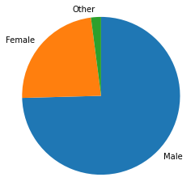

```python
#which gender use the service more?
# we can see in the table and pie chart that 74.5% male vs 23.4% Female vs 2% other
sorted_counts = df_clean['member_gender'].value_counts()
plt.pie(sorted_counts,labels = sorted_counts.index,startangle = 90, counterclock = False);
plt.axis('square');
print('WHICH GENDER USER THE SERVICE MORE')
print((df_clean.member_gender.value_counts()) * 100/173467)
```

**what if we need to know the numbers of riders who share there rides?**

```
NUMBER OF USERS WHO SHARE RIDES
No     89.452749
Yes     9.753440
Name: bike_share_for_all_trip, dtype: float64
```

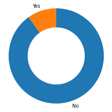

```python
#how many users share there rides
# we can see there that 90% of our users dont share rides vs 9.84% share the ride

sorted_counts = df_clean['bike_share_for_all_trip'].value_counts()

plt.pie(sorted_counts, labels = sorted_counts.index, startangle = 90,
        counterclock = False, wedgeprops = {'width' : 0.4});
plt.axis('square');
print('NUMBER OF USERS WHO SHARE RIDES')
print((df_clean.bike_share_for_all_trip.value_counts()) * 100/173467)
```

**what is the number of our subscriber vs customers?**

```
NUMBER OF SUBSCRIBER VS CUSTOMER
Subscriber    90.069004
Customer       9.137185
Name: user_type, dtype: float64
```

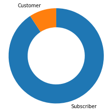

```python
#how many users share there rides
# we can see there that 90% of our users are Subscriber rides vs 9.53% Customer not Subscriber

sorted_counts = df_clean['user_type'].value_counts()

plt.pie(sorted_counts, labels = sorted_counts.index, startangle = 90,
        counterclock = False, wedgeprops = {'width' : 0.4});
plt.axis('square');
print('NUMBER OF SUBSCRIBER VS CUSTOMER')
print((df_clean.user_type.value_counts()) * 100/173467)
```

##### how many station we have and what is the top 10 start and end stations?

```python
# use station nunique to see how many station we have
print('Number of stations',df_clean.start_station_name.nunique())
```

```
Number of stations 329
```

```
Top 10 Start and End Stations
```

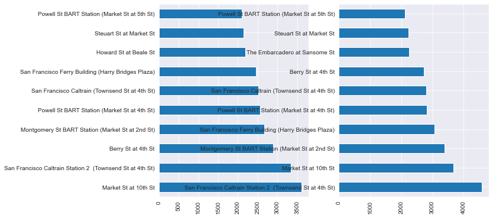

```python
plt.subplot(1, 2, 1)
temp = df_clean.start_station_name.value_counts()
temp2 = temp.head(10)
if len(temp) < 10:
    temp2['remaining {0} items'.format(len(temp) - 10)] = sum(temp[10:0])
temp2.plot(kind='barh')
plt.xticks(rotation=90);

plt.subplot(1, 2, 2)
temp = df_clean.end_station_name.value_counts()
temp3 = temp.head(10)
if len(temp) < 10:
    temp3['remaining {0} items'.format(len(temp) - 10)] = sum(temp[10:0])
temp3.plot(kind='barh')
plt.xticks(rotation=90);
print('Top 10 Start and End Stations')
```

#### what is the minimum used stations?

```
least 10 Start and End Stations
```

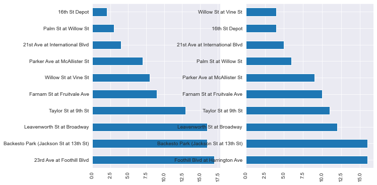

```python
plt.subplot(1, 2, 1)
temp1 = df_clean.start_station_name.value_counts()
temp4 = temp1.tail(10)
if len(temp) < 10:
    temp4['remaining {0} items'.format(len(temp1) - 10)] = sum(temp1[10:0])
temp4.plot(kind='barh')
plt.xticks(rotation=90);

plt.subplot(1, 2, 2)
temp01 = df_clean.end_station_name.value_counts()
temp5 = temp01.tail(10)
if len(temp) < 10:
    temp5['remaining {0} items'.format(len(temp01) - 10)] = sum(temp01[10:0])
temp5.plot(kind='barh')
plt.xticks(rotation=90);
print('least 10 Start and End Stations')
```

### below we can see the bar plot of the rush hour.

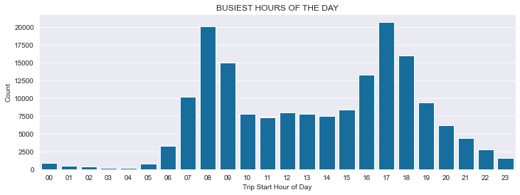

```python
# build plot to see which hour of the day is the rush hour

plt.rcParams['figure.figsize'] = 12,4
base_color = sb.color_palette('colorblind')[0]
sb.set_style('darkgrid')
sb.countplot(data = df_clean, x = 'start_hourofday',color = base_color);
plt.title('BUSIEST HOURS OF THE DAY')
plt.xlabel('Trip Start Hour of Day');
plt.ylabel('Count');
```

### here we will see the number of rides in each day

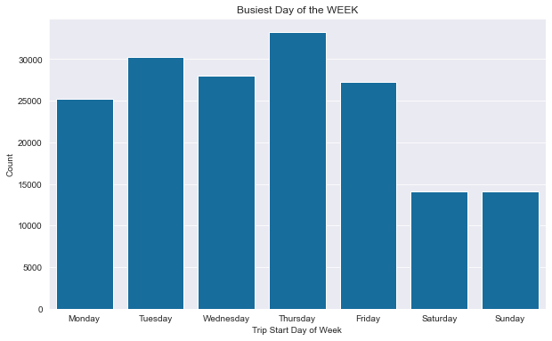

```python
# doing the same to see weekdays
plt.rcParams['figure.figsize'] = 10,6

weekdays = ['Monday', 'Tuesday', 'Wednesday', 'Thursday', 'Friday', 'Saturday', 'Sunday']
weekdays_categories = pd.api.types.CategoricalDtype(ordered = True, categories = weekdays)
df_clean['start_dayofweek'] = df_clean['start_dayofweek'].astype(weekdays_categories)

sb.countplot(data=df_clean, x='start_dayofweek', color=base_color);
plt.title('Busiest Day of the WEEK')
plt.xlabel('Trip Start Day of Week');
plt.ylabel('Count');
```

### what if we need to know the different in age of our client to be able to make markteing?

- here a bar plot

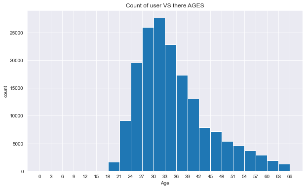

```python
#PLOT the age diffeent of our users
bins = np.arange(0, df_clean['member_age'].max()+3, 3)
plt.hist(data = df_clean, x = 'member_age',bins = bins)
plt.xticks(bins,bins)
plt.xlabel('Age')
plt.ylabel('count');
plt.title('Count of user VS there AGES')
```

### plot the duration in minutes of overall rides.

- we can see that rides is overall between 3 to 10 min.

```
The Mean of all the trips is  10.306736881864353
```

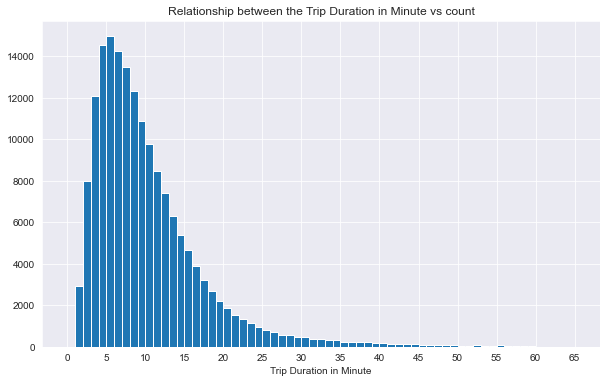

```python
#plot the Trip Duration in Minute
bins = np.arange(0, 66, 1)
ticks = np.arange(0, 66, 5)
plt.hist(data=df_clean, x='duration_minute', bins=bins);
plt.xticks(ticks, ticks);
plt.xlabel('Trip Duration in Minute');
plt.title('Relationship between the Trip Duration in Minute vs count')
print('The Mean of all the trips is ',df_clean.duration_minute.mean())
```

# Bivariate Exploration

### here we can see the different between usertype and trip duration, the subscriber trip duration is less than customer

```
here we can see the Trip Duration in Minute and the Type of user, we can see that Subscriber user the rides for shorter time                than customer
```

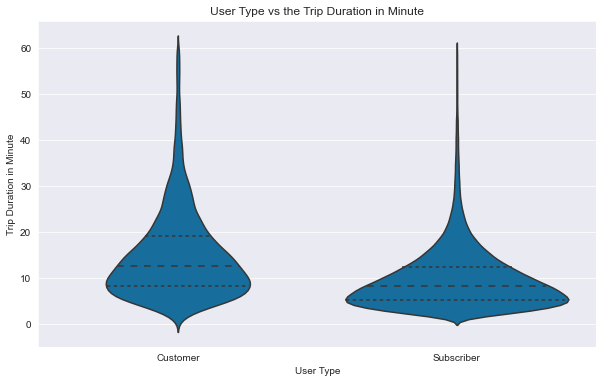

```python
# plot the the types of users vs the duration minute
sb.violinplot(data=df_clean, x='user_type', y='duration_minute', color=base_color, inner='quartile');
plt.xlabel('User Type');
plt.ylabel('Trip Duration in Minute');
plt.title('User Type vs the Trip Duration in Minute');
print('here we can see the Trip Duration in Minute and the Type of user, we can see that Subscriber user the rides for shorter time'
      '                than customer')
```

### here we can see the different between gender and trip duration, the male trip duration is less than female and other

```
male riders tend to have shorter trips compared to female and other users, indicated by both a smaller median and shorter IQR
```

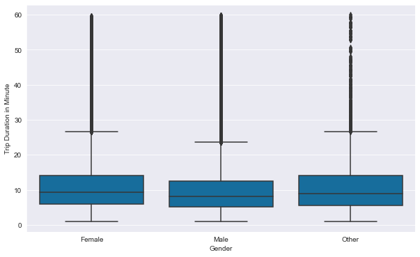

```python
sb.boxplot(data=df_clean, x='member_gender', y='duration_minute', color=base_color);
plt.xlabel('Gender');
plt.ylabel('Trip Duration in Minute');
print('male riders tend to have shorter trips compared to female and other users, indicated by both a smaller median and shorter IQR')
```

#### here we can see that trip duration rise in weekend which make since bec. people have more time

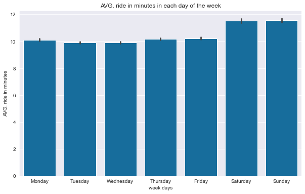

```python
sb.barplot(data = df_clean, x = 'start_dayofweek', y = 'duration_minute',color = base_color)
plt.xlabel('week days')
plt.ylabel('AVG. ride in minutes')
plt.title('AVG. ride in minutes in each day of the week');
```

#### plot different plot type just to see that gender different vs duration in min.

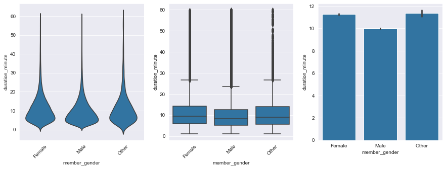

```python
plt.figure(figsize = [15, 5])
base_color = sb.color_palette()[0]
# left plot: violin plot
plt.subplot(1, 3, 1)
sb.violinplot(data=df_clean,x='member_gender', y='duration_minute',inner = None,
              color = base_color)
plt.xticks(rotation = 45); # include label rotation due to small subplot size
# center plot: box plot
plt.subplot(1, 3, 2)
sb.boxplot(data=df_clean, x='member_gender', y='duration_minute', color = base_color)
plt.xticks(rotation = 45);
# right plot: adapted bar chart
plt.subplot(1, 3, 3)
sb.barplot(data=df_clean,x='member_gender', y='duration_minute', color = base_color)
```

# Multivariate Exploration

### here i tried to see the relationship between the Day of Week,Avg. Trip Duration in Minute and the user was customer or subscriber, and we can see that customer number rise at weekend and trip duration rised with it

```
**here i tried to see the relationship between the Day of Week,Avg. Trip Duration in Minute and the user was customer or subscriber**
```

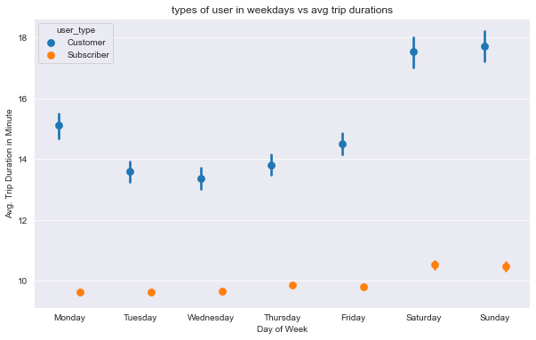

```python
sb.pointplot(data=df_clean, x='start_dayofweek', y='duration_minute', hue='user_type', dodge=0.3, linestyles="");
plt.title('types of user in weekdays vs avg trip durations')
plt.xlabel('Day of Week');
plt.ylabel('Avg. Trip Duration in Minute');
print('**here i tried to see the relationship between the Day of Week,Avg. Trip Duration in Minute and the user was customer or subscriber**')
```

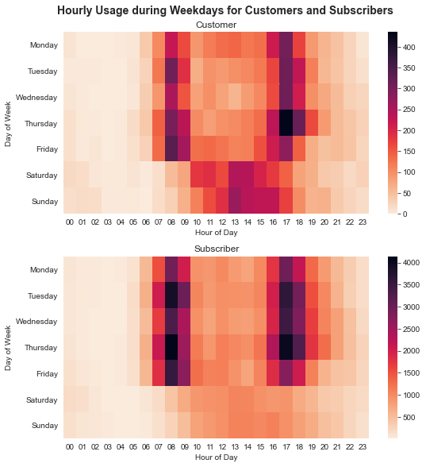

```python
plt.figure(figsize=[8, 8]);

plt.subplot(2, 1, 1)
customers = df_clean.query('user_type == "Customer"')
ct_counts = customers.groupby(['start_dayofweek', 'start_hourofday']).size()
ct_counts = ct_counts.reset_index(name='count')
ct_counts = ct_counts.pivot(index='start_dayofweek', columns='start_hourofday', values='count')
sb.heatmap(ct_counts, cmap='rocket_r');
plt.title('Customer', loc='center');
plt.xlabel('Hour of Day');
plt.ylabel('Day of Week');
plt.tight_layout();


plt.subplot(2, 1, 2)
subscribers = df_clean.query('user_type == "Subscriber"')
st_counts = subscribers.groupby(['start_dayofweek', 'start_hourofday']).size()
st_counts = st_counts.reset_index(name='count')
st_counts = st_counts.pivot(index='start_dayofweek', columns='start_hourofday', values='count')
sb.heatmap(st_counts, cmap='rocket_r');
plt.title('Subscriber', loc='center');
plt.xlabel('Hour of Day');
plt.ylabel('Day of Week');
plt.tight_layout();
plt.suptitle('Hourly Usage during Weekdays for Customers and Subscribers', fontsize=14, fontweight='semibold', y=1.015);
```

Subscribers ride much shorter/quicker trips compared to customers on each day of the week. Both user types had an obvious increase of trip duration on Saturdays and Sundays (or weekends), especially casual customers. Subscriber usage was more efficient than customers overall and maintained a pretty consistent average duration Monday through Friday.